# The Quantum Frontier

Why the Next Generation of Brain-Computer Interfaces Needs Quantum-Aware Protection

Author

Kevin Qi, with Claude (Anthropic)

Published

February 2, 2026

**NoteContent Pending**

This chapter’s core content is drafted in QIF-WHITEPAPER.md and will be migrated to as-code format. See the full draft for complete text.

## 1 Engaging the Tegmark Objection

Any framework proposing quantum effects in neuroscience must directly confront Tegmark’s (2000) decoherence argument. We do so here.

### 1.1 The Original Argument

Tegmark calculated decoherence times of 10⁻¹³ to 10⁻²⁰ seconds for quantum superpositions in neural processes — far too short for any biological relevance. His conclusion: “the brain is a classical system for all practical purposes.”

### 1.2 Subsequent Corrections and Challenges

The debate has evolved considerably since 2000:

1. **Hagan, Hameroff & Tuszynski (2002):** Identified errors in Tegmark’s ion-channel model, correcting the estimate by **7 orders of magnitude** to 10–100 μs. They showed that microtubule interiors provide a partially shielded environment.
2. **Dewan (2026):** Demonstrated that Tegmark’s exponential decoherence model assumes Markovian (memoryless) bath dynamics. In finite-memory biological environments, short-time decoherence follows a **quadratic** profile, potentially extending coherence windows further. Tegmark’s bound emerges as a singular Markovian limit.
3. **Fisher et al. (2025):** Reported the first in vitro experimental evidence consistent with quantum effects in Posner molecule formation — differential lithium isotope effects on calcium phosphate aggregation. If Posner molecules are present in neural tissue, nuclear spin coherence could persist for **hours**.
4. **Wiest (2025):** Reports experimental evidence for macroscopic quantum entangled states in living human brain tissue, correlated with conscious state transitions.

### 1.3 QIF’s Position: The Framework Works Either Way

QIF does not require resolving the Tegmark debate. The decoherence time τ_D is a **tunable parameter**, not a fixed assumption. The table below shows how the QI equation responds across the full range of proposed timescales:

Table 1: QI Score Across Decoherence Timescale Positions (t = 1 μs, Cclass = 0.8)

|  | Position | τ_D | Quantum Gate (1−Γ_D) | QI Score |
| --- | --- | --- | --- | --- |
| 0 | Tegmark worst case | 10⁻²⁰ s | 0.000000 | 0.750 |
| 1 | Tegmark (2000) | 10⁻¹³ s | 0.000000 | 0.750 |
| 2 | Hagan et al. (2002) | 10⁻⁴ s (100 μs) | 0.990050 | 1.394 |
| 3 | Recent experimental | 10⁻⁵ s (10 μs) | 0.904837 | 1.338 |
| 4 | Non-Markovian (Dewan 2026) | 10⁻³ s (1 ms) | 0.999000 | 1.399 |
| 5 | Fisher (Posner, 2015/2025) | ~1 hour | 1.000000 | 1.400 |

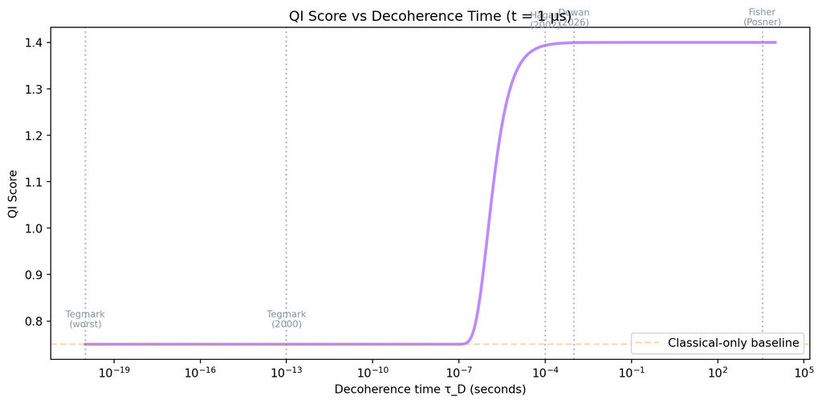

Figure 1: QI score as a function of decoherence time. The framework transitions smoothly from purely classical (left) to quantum-enhanced (right). Vertical lines mark key literature positions.

### 1.4 Key Insight

The QI score transitions **smoothly** from classical-only (τ_D << t) to quantum-enhanced (τ_D >> t). There is no binary “quantum or not” — the framework captures a continuous spectrum. This means:

- **If Tegmark is right:** QIF reduces to a classical coherence-based BCI security metric. The Cₛ metric, hourglass architecture, and threat taxonomy remain novel contributions with no quantum dependency.
- **If Fisher is right:** QIF’s quantum terms become dominant, and the framework provides the first security model that accounts for these effects.
- **If the truth is in between** (the most likely scenario per Hagan/Dewan): QIF captures the partial quantum contribution at whatever timescale experiments reveal.